# Boston House Price Prediction

Sutong Jiang

## Introduction

Zillow, as the leading real estate marketplace in the US, is engaged on offering users the most accrate information of house on sale, among which the Zestimate is a highlight design. The Zestimate shows the estimate sale price of house based on the company’s own algorithm, and when comparing it with the price on board, one can catch if the pursue is ecnomic immediately. Therefore the more accurate Zestimate is, the more trust customers will build with Zillow, and the more competent the company will be among all the real estate marketplace website.

This report shows an attempt to help improve the Zestimate by focusing on both the internal house characteristics, the spatial effect(espeicially neighborhood-wise), and some environmental effects. Commonly we evaluate a house first on its location, and then on its internal features. In Boston some neighborhodds are experiencing a commanding gentrification and it’s probably responsible for the change in price.

The resulting model improve the prediction considerably, with average prediction error percentage of 13.87%.

## Data

### Data Gathering and Cleaning

The data used in this report comes from Boston_Midterms_Dataset, OpenData Boston and Governing.com(details on http://www.governing.com/gov-data/boston-gentrification-maps-demographic-data.html). Selected data has been statistically transformed for better modeling. Also, data has been cleaned and 95% of the houses in Boston real estate marke are included.

The categories of data are:

**Internal House Characteristics** Those are characteristics of the house itself, including the registeded land use type.

**Locality Characteristics** Features on the scale of neighborhood and census tract are included.

**Environmental characteristics** These characteristics reflect how the quality of environment will affect on the house price.

### Data Description

#### Variable Description

The following table shows the variables used in this report and their meanings.

Variable List

| Type | Name | Meaning |
| --- | --- | --- |
| Dependent Variable | LnSalePrice | Sale Price of the property (log-transformed) |
| Internal Predictor | LnLAND_SF | Parcel’s land area in square feet (log-transformed) |
| Internal Predictor | LnLIVING_ARE | Total building livable square feet (log-transformed) |
| Locality Predictor | LnDistToCBD | Distance to CBD of Boston(log-transformed) |
| Locality Predictor | LnMEDHHINC | Median household income of census block group(log-transformed) |
| Locality Predictor | LnDist_Major | Distance to road with speed limit over 35 mph (feet,log-transformed) |
| Locality Predictor | LnAve_SalePr | Average sale price of 5 nearest homes(log-transformed) |
| Environmental Predictor | LnALAND | Size of land in the census block group(log-transformed) |
| Internal Predictor | R_BDRMS | Number of bedrooms |
| Internal Predictor | R_FULL_BTH | Number of full bathrooms |
| Internal Predictor | R_HALF_BTH | Number of half bathrooms |
| Internal Predictor | R_FPLACE | Number of fireplaces in the structure |
| Internal Predictor | NUM_FLOORS | Number of floors |
| Locality Predictor | SchoolGrade | Ranking of nearest public school(1-9)from greatschool.com |
| Locality Predictor | GENTRI_S_1 | Degree of gentrification of the census track(0-2) |
| Locality Predictor | NearUni | within one kilometer of university (binary) |
| Locality Predictor | WalkScore | score of walkability of the neighborhood |
| Locality Predictor | BikeScore | score of bike accessibility of the neighborhood |
| Locality Predictor | PCTVACANT | Percent of vacant housing units in the block group |
| Locality Predictor | PCTBACHMOR | Percent of population in block group with bachelor’s degree or more |
| Locality Predictor | PCTWHITE | Percent of population in block group which identify as white |
| Locality Predictor | CrimeIndex | Crime ranking based on density of violent crime occurrences in 2015 (1-6) |

#### Summary statistics

Below is the summary of statistics on variables before transformed.

Summary Statistics

|  | Mean | Median | SD | Max | Min |
| --- | --- | --- | --- | --- | --- |
| SalePrice | 578,495.018 | 495,000.000 | 570,357.399 | 11,600,000.00 | 0.000 |
| LAND_SF | 4,536.120 | 4,237.000 | 3,285.824 | 63,941.00 | 480.000 |
| LIVING_ARE | 2,281.758 | 2,103.000 | 993.882 | 9,908.00 | 573.000 |
| DistToCBD | 27,165.123 | 28,095.000 | 13,277.229 | 52,892.00 | 2,231.000 |
| MEDHHINC | 73,312.559 | 68,125.000 | 30,707.855 | 166,375.00 | 9,756.000 |
| Dist_Major | 2,703.619 | 2,053.921 | 2,528.078 | 15,749.20 | 3.011 |
| ALAND10 | 1,020,709.858 | 684,298.000 | 908,709.913 | 4,344,387.00 | 76,782.000 |
| Ave_SalePr | 641,689.318 | 517,000.000 | 454,467.943 | 4,470,000.00 | 283,541.000 |
| SchoolGrade | 3.123 | 3.000 | 1.726 | 9.00 | 1.000 |
| WalkScore | 85.522 | 86.000 | 5.549 | 98.00 | 70.000 |
| BikeScore | 65.628 | 64.000 | 12.524 | 95.00 | 53.000 |
| PCTVANAT | 4.600 | 4.000 | 3.046 | 28.00 | 0.000 |
| PCTBACHMOR | 39.634 | 37.000 | 22.648 | 97.00 | 0.000 |
| R_BDRMS | 4.506 | 4.000 | 2.019 | 14.00 | 1.000 |
| R_FULL_BTH | 1.988 | 2.000 | 0.891 | 8.00 | 1.000 |
| R_HALF_BTH | 0.367 | 0.000 | 0.551 | 3.00 | 0.000 |
| R_FPLACE | 0.412 | 0.000 | 0.770 | 7.00 | 0.000 |
| PCTWHITE | 59.947 | 68.000 | 31.279 | 100.00 | 2.000 |
| CrimeIndex | 3.962 | 3.550 | 1.948 | 9.61 | 1.000 |

#### Correlation Matrix

Below is the correlation matrix of variables in model, proving there’s no strong pairwise predictors(no correlation larger than 0.8), as a test of multi-collinearity in statistics. The correlation between Ave_SalePr and LnSalePrice is 0.82, indicating that the average sale price of the nearest 5 houses is a very important predictor on house price.

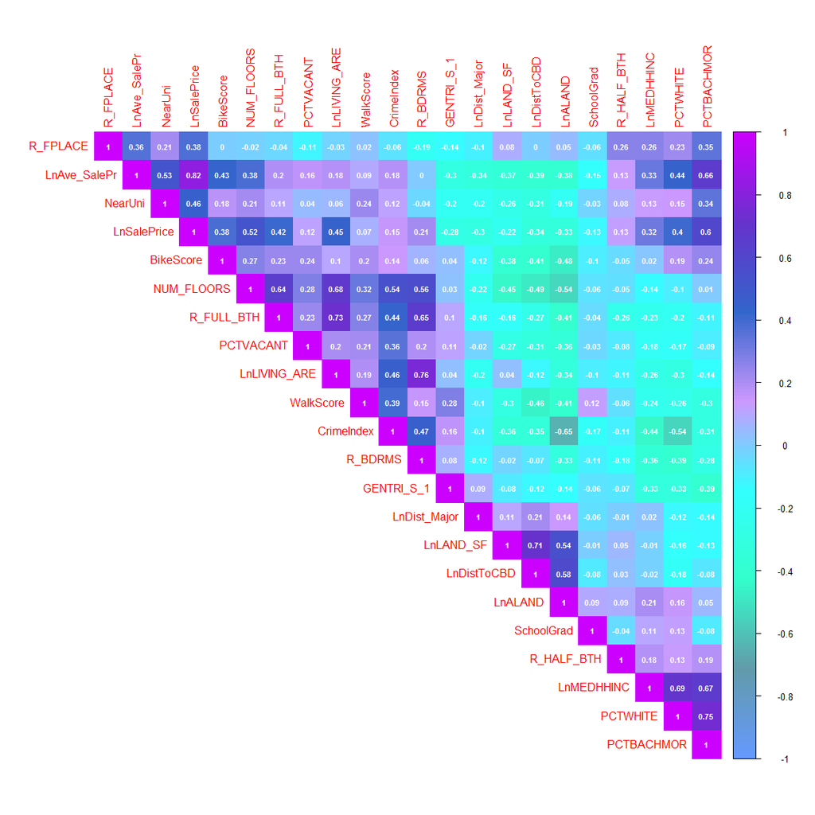

#### Variable Distribution across Neighborhoods

Report will show latter a test of spatial cross validation on neighborhoods of three price levels, and below is the variable distribution boxplots of the three chosen neighrborhoods: South End, South Boston and Mattapan. Be careful that these three neighrborhoods are not at the top, bottom or middle along income level, for gentrification also exerts considerable influence on house price.

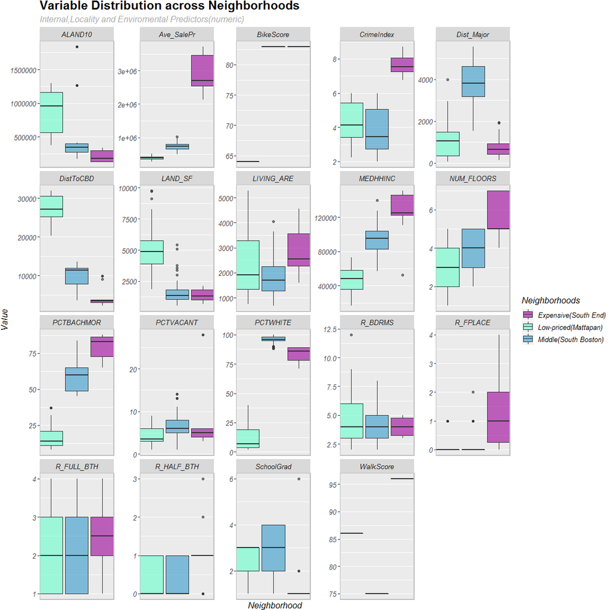

#### Maps of Variables

Next, the report shows the spatial distribution of sale price and three main predictors: Percent of people having Bachelor’s degree and more, Median Household Income of the census block and Gentrification level.

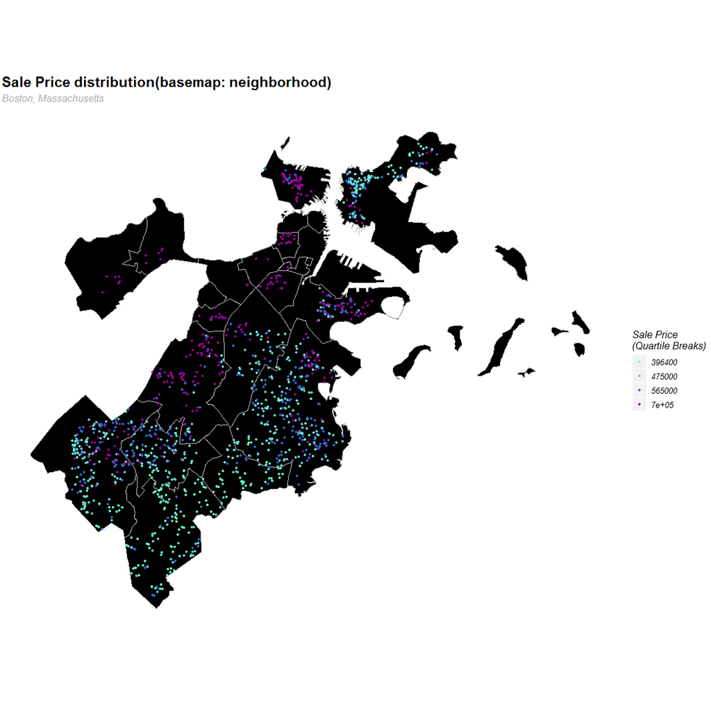

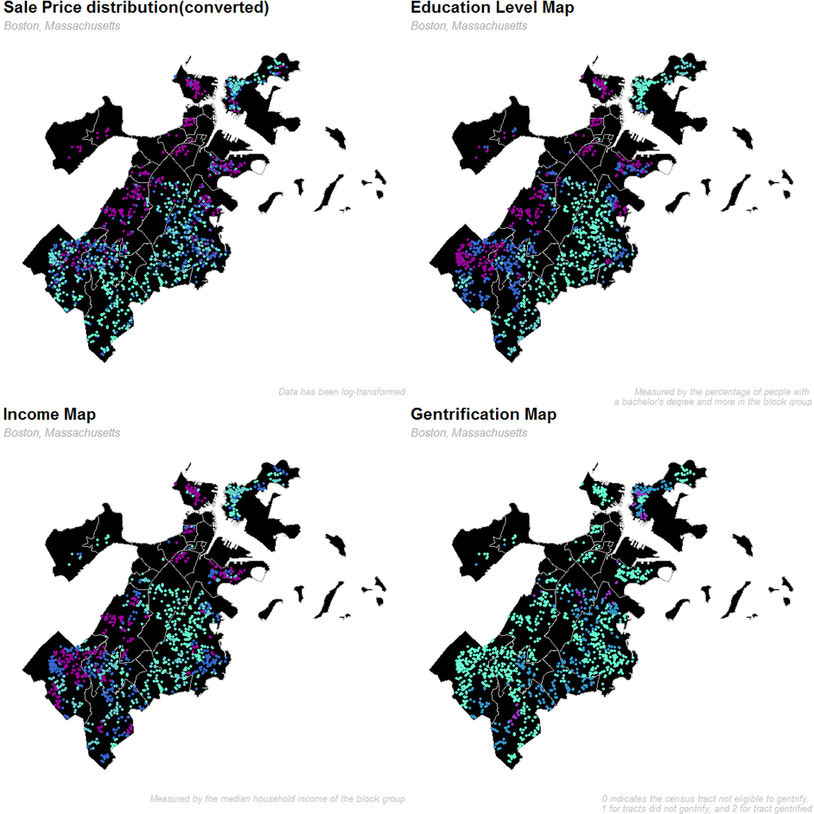

## Methods

### Data Transformation and Cleaning

Since the dependent variable SalePrice is highly skewed, it’s better for modeling to log-transform it to be normal-distributed, and so do some of the highly-skewed continuous dependent variables. Thus, other continuous variables distributed in the same range should all be log-transformed in order to unite the contribution at the same level.

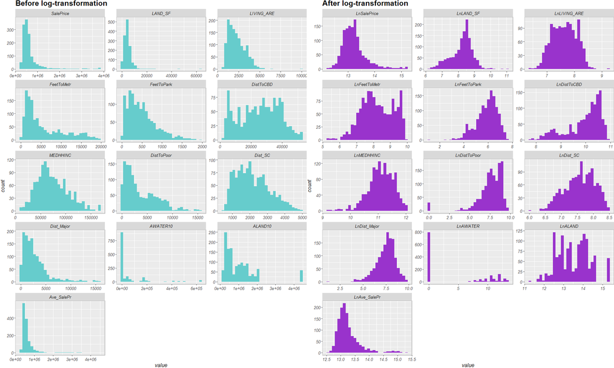

Data cleaning is designated according to the the degree of discretion of sale price. First the report draws sale price as a function of median household income of the block group house located, and the scatter plot below shows a slight linear relationship between the two, with unrealistic values of 0, which needs to be removed, and outliers with sale price larger than 3,000,000. After capping out the top 5% of data we reduce the degree of discretion to an acceptable level(see the comparison of two boxplots).

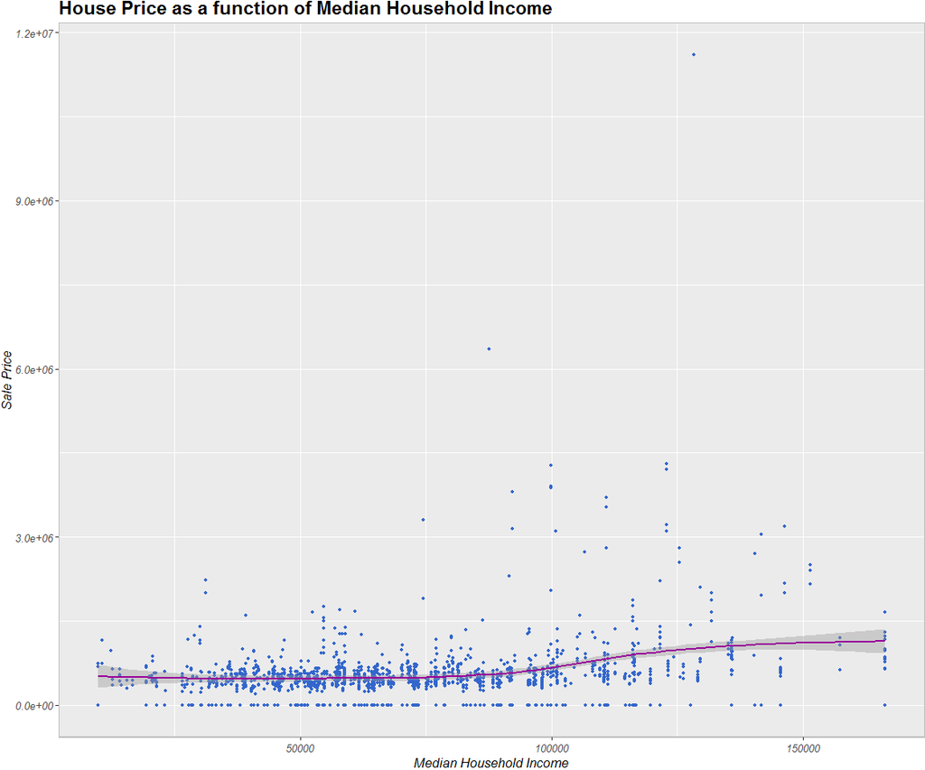

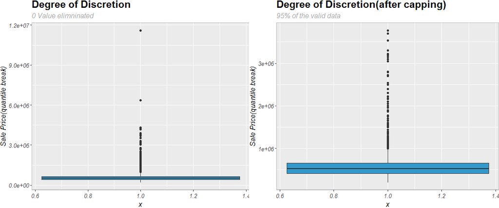

### Modeing Methods

The report applied stepwise regression to automatically test the quality of our predictors and see if there is a better model. Stepwise regression analyses the deviation table of variables and sequentially kicks out the unimportant variables. The final variable list shows the result.

### Evaluation Method

The report evaluated the model from three aspects: out-of-sample modling, k-folder cross validation and spatial cross validation.

Out-of-sample modeling tries to test the model efficiency when it predicts new data out of its training set. Therefore in this report 25% of the dataset is randomly selected as the test set and the rest as the training set.

K-folder cross validation is a further way of out-of-sample modeling. Data set is equally distributed into k folders as the test set, for each the rest as training set, and regression is applied for k times.

Similar to k-folder cross validation, in spatial cross validation neighborhoods of three price levels are selected as test sets with the rest as training set. Regression is applied for three times and the comparison is enlightening.

## Results

### In-Sample Model Results

After comparison of models with close AIC, the report picks the best model through the model with the number of predictors that optimizes AIC and RSquared. The formula is as follows:

```r
formula <- LnSalePrice ~  NUM_FLOORS + GENTRI_S_1 +
  NearUni + WalkScore + BikeScore + PCTBACHMOR +
  R_FULL_BTH + R_HALF_BTH + R_FPLACE + PCTVACANT+ PCTWHITE + CrimeIndex +
  SchoolGrad+ LnLAND_SF + LnLIVING_ARE + LnDistToCBD + LnMEDHHINC + LnDist_Major +
  LnALAND + LnAve_SalePr
```

In-Sample Prediction Results(on log-transformed sale price)

|  | RSquared | Adjusted_RSquared | Num_Predictors | Num_Observations |
| --- | --- | --- | --- | --- |
| In-Sample Prediction | 0.8463272 | 0.8439666 | 20 | 1,302 |

|  | Estimate | Std. Error | t value | Pr(>\|t\|) |  |
| --- | --- | --- | --- | --- | --- |
| **(Intercept)** | 3.117 | 0.4428 | 7.039 | 3.119e-12 | * * * |
| **NUM_FLOORS** | 0.04004 | 0.007128 | 5.618 | 2.366e-08 | * * * |
| **GENTRI_S_1** | -0.02021 | 0.01036 | -1.95 | 0.05138 |  |
| **NearUni** | 0.0777 | 0.01693 | 4.591 | 4.839e-06 | * * * |
| **WalkScore** | -0.001203 | 0.001204 | -0.9986 | 0.3182 |  |
| **BikeScore** | 0.001504 | 0.0005087 | 2.957 | 0.003161 | * * |
| **PCTBACHMOR** | 0.002586 | 0.0004807 | 5.38 | 8.83e-08 | * * * |
| **R_FULL_BTH** | 0.06763 | 0.008951 | 7.556 | 7.808e-14 | * * * |
| **R_HALF_BTH** | 0.04124 | 0.009817 | 4.2 | 2.845e-05 | * * * |
| **R_FPLACE** | 0.05778 | 0.007602 | 7.601 | 5.576e-14 | * * * |
| **PCTVACANT** | -0.002454 | 0.00182 | -1.348 | 0.1779 |  |
| **PCTWHITE** | 0.001559 | 0.0003455 | 4.512 | 7.017e-06 | * * * |
| **CrimeIndex** | -0.01136 | 0.004831 | -2.351 | 0.01887 | * |
| **SchoolGrad** | -0.004233 | 0.003167 | -1.337 | 0.1815 |  |
| **LnLAND_SF** | 0.06956 | 0.01286 | 5.409 | 7.519e-08 | * * * |
| **LnLIVING_ARE** | 0.268 | 0.02187 | 12.25 | 9.627e-33 | * * * |
| **LnDistToCBD** | -0.03487 | 0.0125 | -2.79 | 0.00534 | * * |
| **LnMEDHHINC** | 0.03766 | 0.01651 | 2.281 | 0.0227 | * |
| **LnDist_Major** | 0.01013 | 0.005311 | 1.907 | 0.05672 |  |
| **LnALAND** | -0.0147 | 0.01032 | -1.424 | 0.1546 |  |
| **LnAve_SalePr** | 0.5377 | 0.02485 | 21.63 | 6.439e-89 | * * * |

Table: Fitting linear model: formula The model is considerably efficient based on the error margin

In-Sample Prediction Evaluation (on log-transformed sale price)

|  | Rsquared | RMSE | MAE | Error_margin |
| --- | --- | --- | --- | --- |
| In-Sample Prediction | 0.8463272 | 0.1768563 | 0.1368867 | 0.1387472 |

#### Out-of-Sample Model

The gap between error margins of in-sample and out-of-sample prediction is acceptable.

Prediction Results of two models

|  | Rsquared | RMSE | MAE | Error_margin |
| --- | --- | --- | --- | --- |
| In-Sample | 0.8463272 | 0.1768563 | 0.1368867 | 0.1387472 |
| Out-of-Sample | 0.8189586 | 0.1791037 | 0.1376339 | 0.1385987 |

#### Cross Validation

Cross Validation Evaluation Measure

|  | mean_Rsquared | std_Rsquared |
| --- | --- | --- |
| Cross Validation | 0.8372453 | 0.0345981 |

#### Spatial Cross Validation

After ranking the average sale price of neighborhoods, South End is selected as the most expensive neighrborhood, South Boston as the middle and Mattapan as the low-priced one. The following table shows that the r-squareds of three regression lie in satisfying range from 0.821 to 0.851.

Prediction Results on Neighborhoods of 3 Price Levels

| Name | Type | Rsquared | RMSE | MAE | Error_margin1 |
| --- | --- | --- | --- | --- | --- |
| South End | Expensive | 0.8209549 | 0.3522876 | 0.3256834 | 0.2714912 |
| South Boston | Middle | 0.8509900 | 0.2081952 | 0.1707202 | 0.1677464 |
| Mattapan | Low-priced | 0.8450660 | 0.1573335 | 0.1286434 | 0.1225452 |

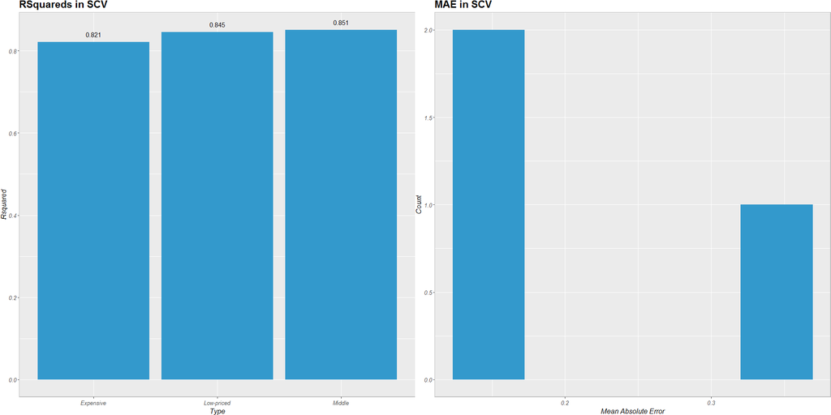

### Regression Assumption Checks

This part tests model assumptions and aptness.

#### Test of Heteroscadasticity

The scatter plot of standardized residuals as a function of predicted values in out-of-sample model shows a barely equal variance of residuals along the predicted value, which is satisfying. However, there is an outlier, and a slight tendancy of smaller variance of residuals when the predicted values are large.

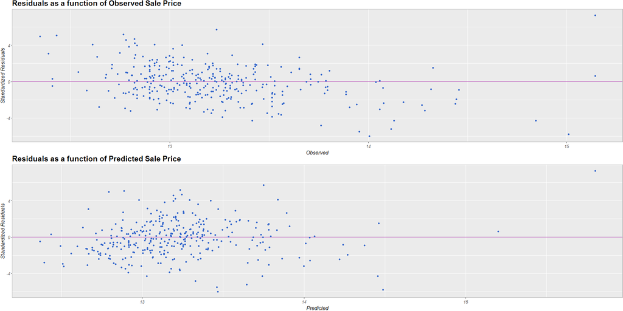

#### Test of Spatial Auto Correlation

The test results indicate there’s no significant spatial auto correlation present in the residuals.

Spatial Autocorrelation Test

|  | p-value | Moran I statistic | Expectation | Variance |
| --- | --- | --- | --- | --- |
| Summary | 0.8995936 | -0.0492725 | -0.0030488 | 0.0013057 |

Here is the map of residuals in support of the conclusion.

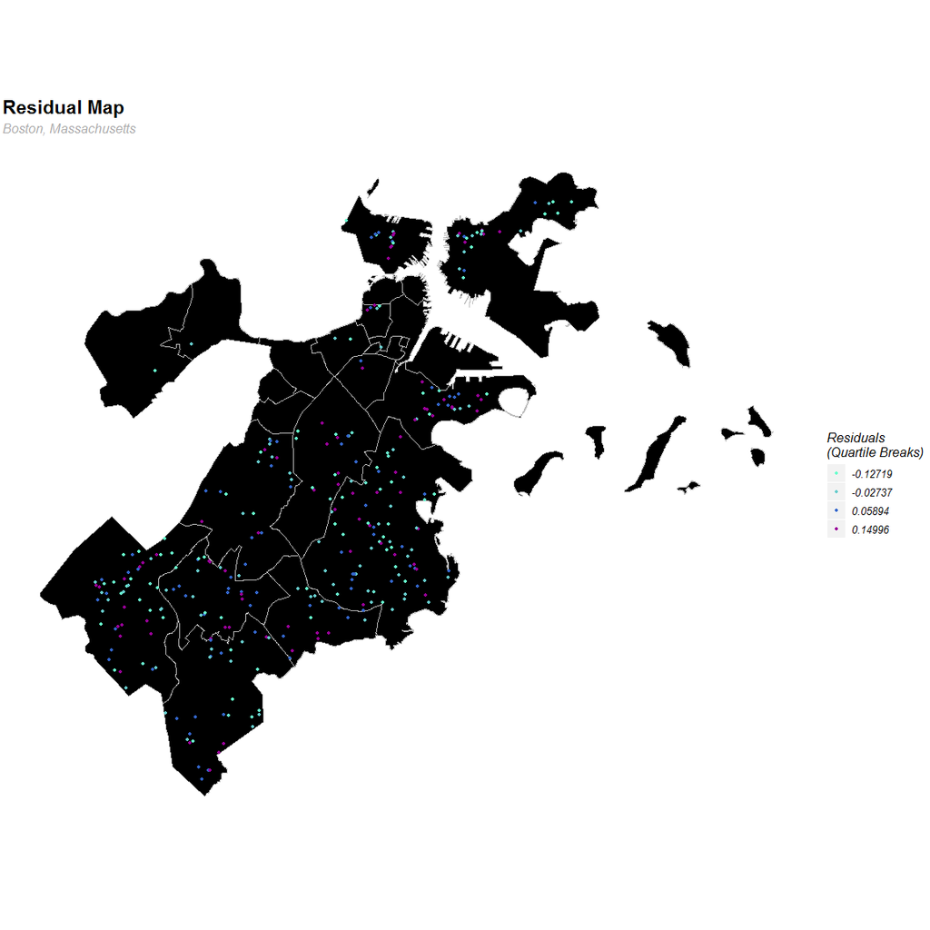

### Maps

The following map shows the predicted price of the model training on data set with 1302 observations.

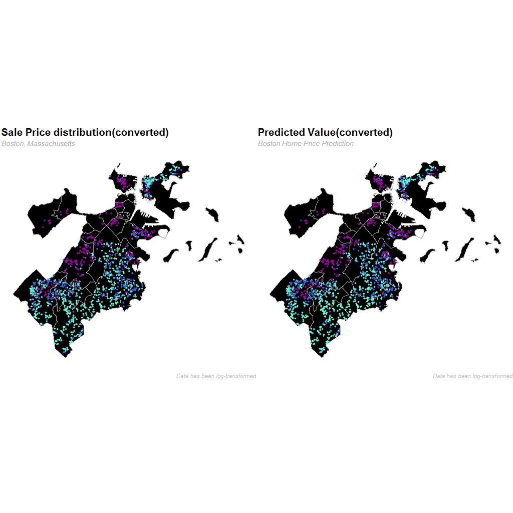

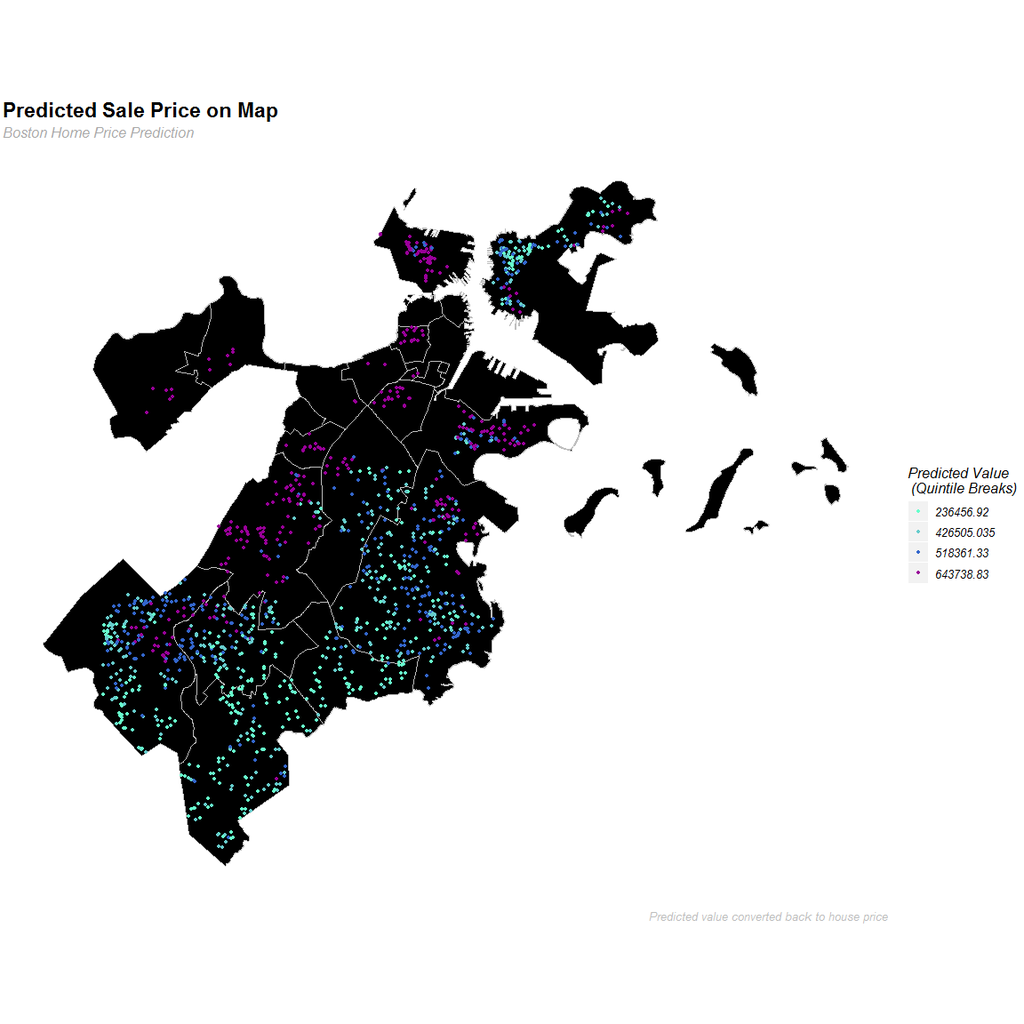

The following table and map shows the distribution of Error margin across neighborhoods.

Prediction Statistics by Neighborhood

| Name | Error_margin | Ave_SalePrice | Count |
| --- | --- | --- | --- |
| Allston | 0.1202549 | 1,160,833 | 6 |
| Beacon Hill | 0.2007743 | 2,753,431 | 14 |
| Brighton | 0.1808566 | 936,333 | 6 |
| Charlestown | 0.1698701 | 961,667 | 60 |
| Dorchester | 0.1309984 | 522,938 | 307 |
| East Boston | 0.1733687 | 490,170 | 137 |
| Hyde Park | 0.1189731 | 405,211 | 135 |
| Jamaica Plain | 0.1304726 | 843,243 | 103 |
| Mattapan | 0.1158942 | 398,102 | 56 |
| Mission Hill | 0.1732265 | 1,363,538 | 13 |
| Roslindale | 0.1106599 | 493,255 | 126 |
| Roxbury | 0.1853853 | 523,007 | 57 |
| South Boston | 0.1660501 | 728,820 | 69 |
| South End | 0.1873682 | 2,794,417 | 18 |
| West Roxbury | 0.1234572 | 533,238 | 210 |

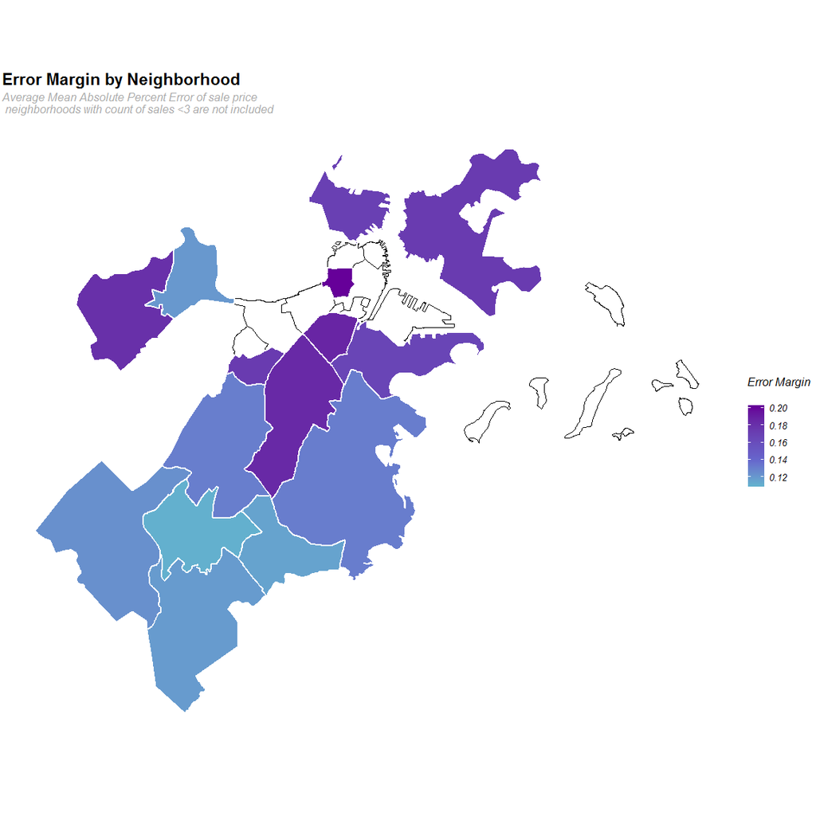

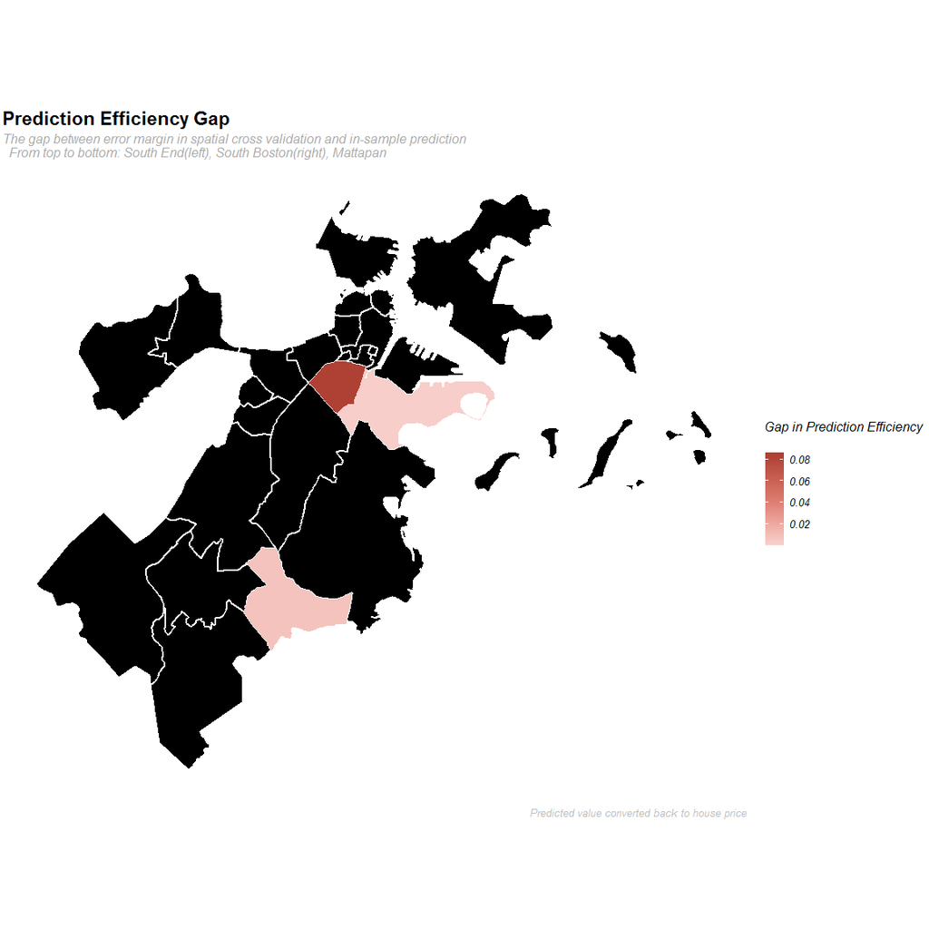

## Discussion

In all the model is effective in predicting house price in Boston, especially in middle and low-priced real estate. Due to degree of discretion of data with price of luxury houses much higher than 75% of all house, it’s better for ridge or lasso regression. However, there should be cautious condiseration of predictors put into ridge or lasso regression.

Education level of citizens, household income, and gentrification map are three interesting variables. The spatial distribution of income and education level resemble each other, and in commons influence the sale price. However houses in and around CBD shows a reverse pattern of price and the two elements. Considering the gentrification distribution, with most of the tracts in and around CBD gentrified or eligible to gentriy yet not, the reverse pattern makes sense.

The Ave_Salepr, which is the average sale price of the nearest 5 houses, has the largest coefficient(except for intercept) among all predictors, indicates strong spatial pattern in sale price. Residuals are randomly distributed across neighborhoods, with a slightly smaller variance on the high sale price predicted.

In all, expensive houses locate in northern and western part of Boston, close to the university town, and middle as well as low priced houses scattered in the central city,southern and eastern part, including East boston at the east side of Charles River. The model did a good job on predicting price in middle and low priced housing area, while average performance on expensive houses. The result is likely to estimate for OLS regression model is not good at statistics which is not normally distributed.

## Conclusion

This report states clearly the price model predicting 95% of the house in Boston real estate market and the model is worth applying on the website. Taking average price of the nearest 5 houses into account, this model needs to included the average sale price of the nearest 20 houses for a more generalizing spatial pattern.

Also, factor variables like Style(style of the structure of house), R_AC(type of air conditioning of the house)have strong influence on sale price, however, the limited observations of some categories restrict the out-of-sample modeling. It’s worth learning how to take these variables into effect.

Other than spatial cross validation, cluster analysis as a way of machine learning can be applied on the full dataset with the predictors in the formula. Number of groups can be tested from 4 to 10 due and check the final result on similarity.